# CITS4009 - Project 1

## 5.2 Distribution of video views

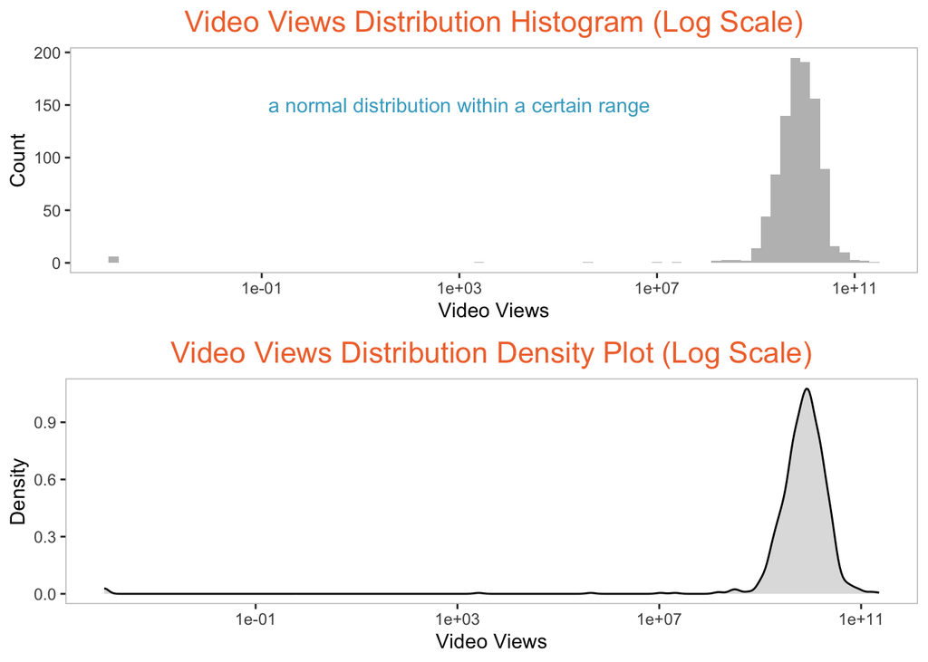

```r
p3 <- ggplot(data = youtubedata, aes(x = video.views)) +
  geom_histogram(binwidth = 0.2, fill = "grey") +
  scale_x_log10() +
  labs(title = "Video Views Distribution Histogram (Log Scale)",
       x = "Video Views",
       y = "Count")+common_theme +
  annotate("text", x = 1e+03, y = 150, label = "a normal distribution within a certain range", color = "#44aac9")

p4 <- ggplot(data = youtubedata, aes(x = video.views)) +
  geom_density(fill = "grey", alpha = 0.5) +
  scale_x_log10() +
  labs(title = "Video Views Distribution Density Plot (Log Scale)",
       x = "Video Views",
       y = "Density")+common_theme

grid.arrange(p3, p4, ncol = 1)
```

It can be observed that the ‘video_views’ variable may exhibits a normal distribution within a certain range.

## 5.3 Distribution of channel types

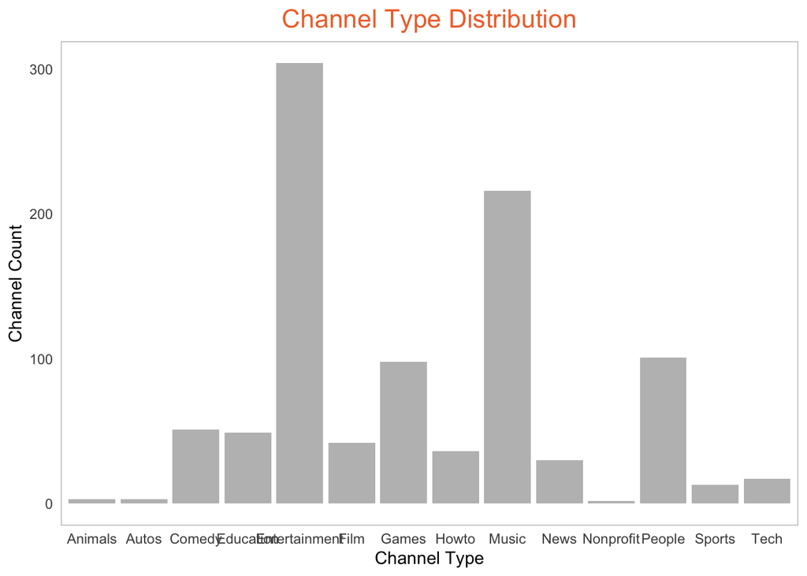

```r
ggplot(youtubedata, aes(x = channel_type)) +
  geom_bar(fill = "grey") +
  labs(title = "Channel Type Distribution", x = "Channel Type", y = "Channel Count") +
  theme_minimal() +
  common_theme_2
```

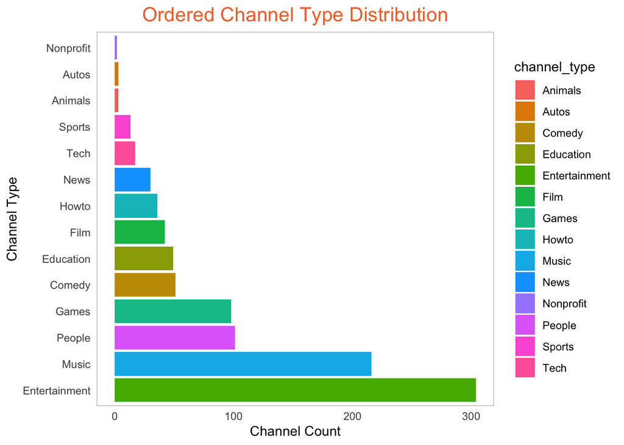

```r
channel_type_o<- youtubedata %>%
  count(channel_type) %>%
  arrange(desc(n)) %>%
  pull(channel_type)


ggplot(youtubedata, aes(x = factor(channel_type, levels = channel_type_o), fill = channel_type)) +
  geom_bar() +
  labs(title = "Ordered Channel Type Distribution", y = "Channel Count", x = "Channel Type") +
  theme_minimal() +
  coord_flip() +
  common_theme_2
```

Nonprofit has the lowest count, while Entertainment has the highest count.

## 5.4 Relationships of Subscribers and Video Views

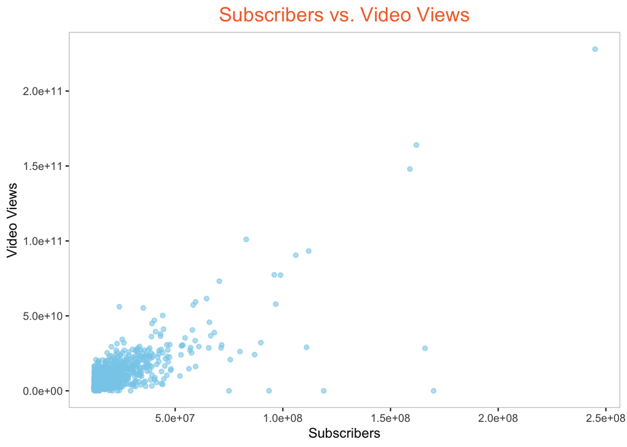

```r
p5<- ggplot(youtubedata, aes(x = subscribers, y = video.views)) +
  geom_jitter(color = "skyblue", alpha = 0.6, width = 0.2, height = 0.2) +
  labs(title = "Subscribers vs. Video Views",
       x = "Subscribers", y = "Video Views") +
  common_theme
print(p5)
```

Despite using geom_jitter(), severe overlap persists. Trying Hexbin scatter plots and kernel density estimation to enhance visualization.

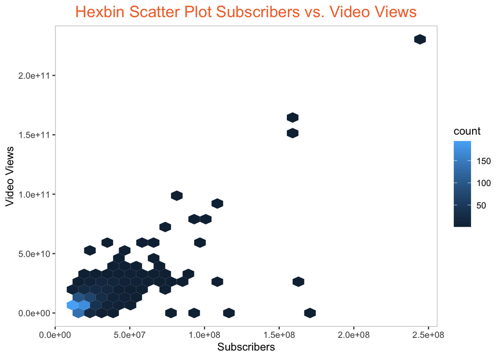

```r
p6 <- ggplot(youtubedata, aes(x = subscribers, y = video.views)) +
  geom_hex() +
  labs(title = "Hexbin Scatter Plot Subscribers vs. Video Views",
       x = "Subscribers", y = "Video Views") +
  common_theme
print(p6)
```

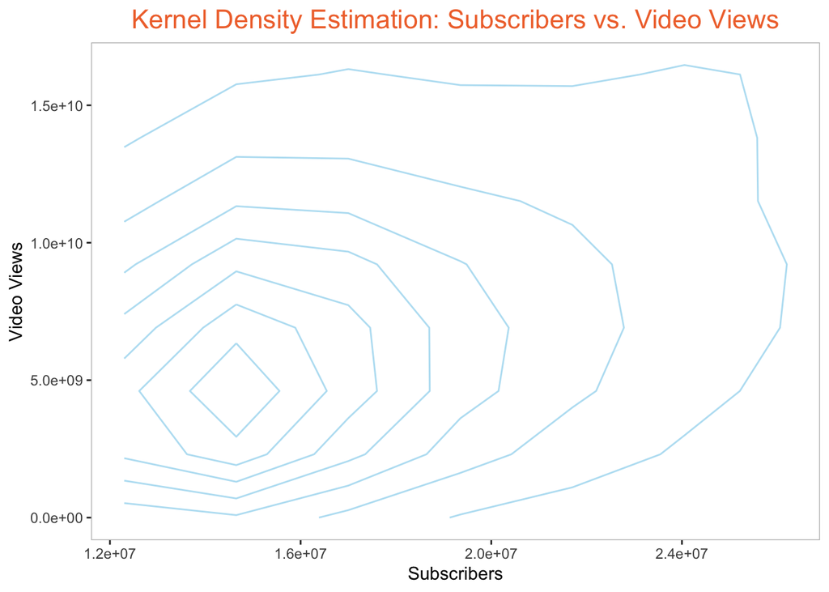

```r
p7 <- ggplot(youtubedata, aes(x = subscribers, y = video.views)) +
  geom_density_2d(color = "skyblue", alpha = 0.6) +
  labs(title = "Kernel Density Estimation: Subscribers vs. Video Views",
       x = "Subscribers", y = "Video Views") +
  common_theme
print(p7)
```

Exploring the linear regression relationship between subscribers and video views，It can be observed that there may be a correlation between the two variables.

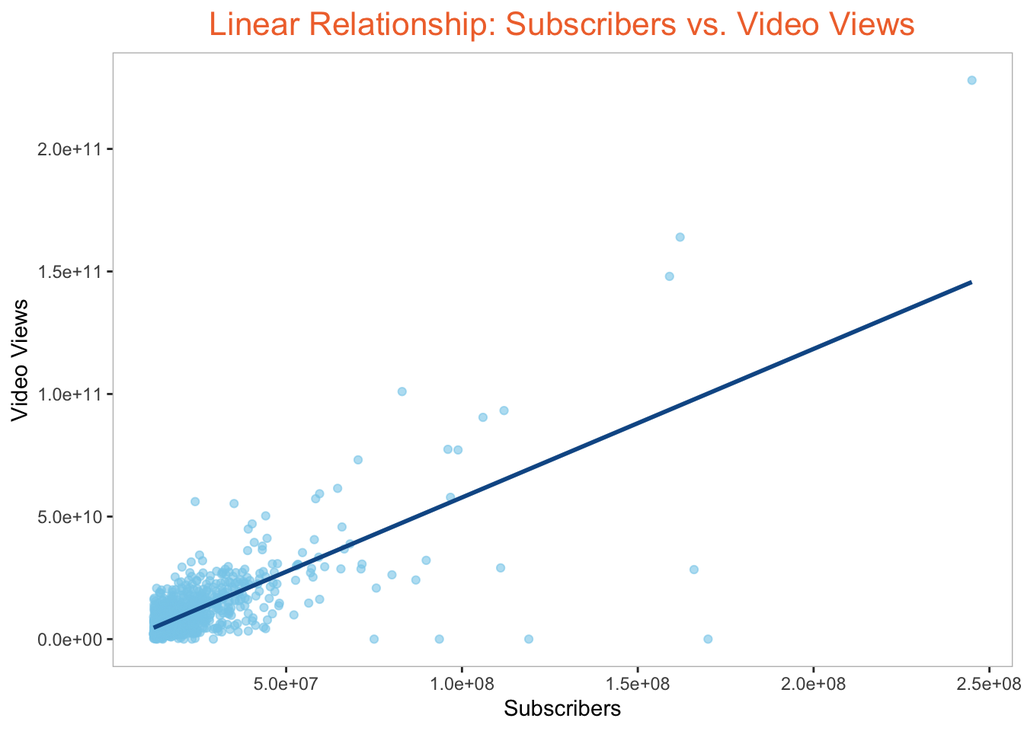

```r
linear_relationship_plot <- ggplot(youtubedata, aes(x = subscribers, y = video.views)) +
  geom_jitter(color = "skyblue", alpha = 0.6) +
  geom_smooth(method = "lm", se = FALSE, color = "#0f5894") +
  labs(title = "Linear Relationship: Subscribers vs. Video Views",
       x = "Subscribers", y = "Video Views") +
  common_theme

print(linear_relationship_plot)
```

## 5.5 Relationships among four different “rank” variables

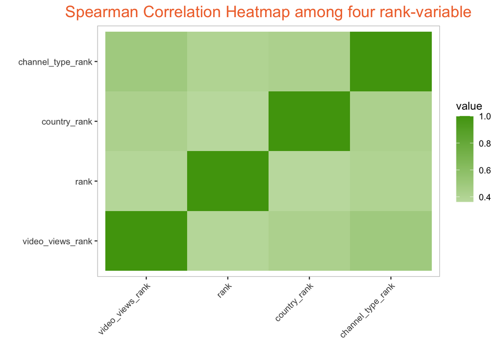

```r
cor_matrix <- cor(youtubedata_rank, use = "pairwise.complete.obs", method = "spearman")

p8<- ggplot(data = melt(cor_matrix), aes(x = Var2, y = Var1, fill = value)) +
  geom_tile() +
  scale_fill_gradient2(low = "blue", high = "#4fa10d", midpoint = 0) +
  labs(title = "Spearman Correlation Heatmap among four rank-variable", x = "", y = "") +
  common_theme +
  theme(axis.text.x = element_text(angle = 45, hjust = 1))
print(p8)
```

It can be observed that there is a certain degree of correlation among the four variables.

## 5.6 Relationship between average subscriber growth amount and channel type

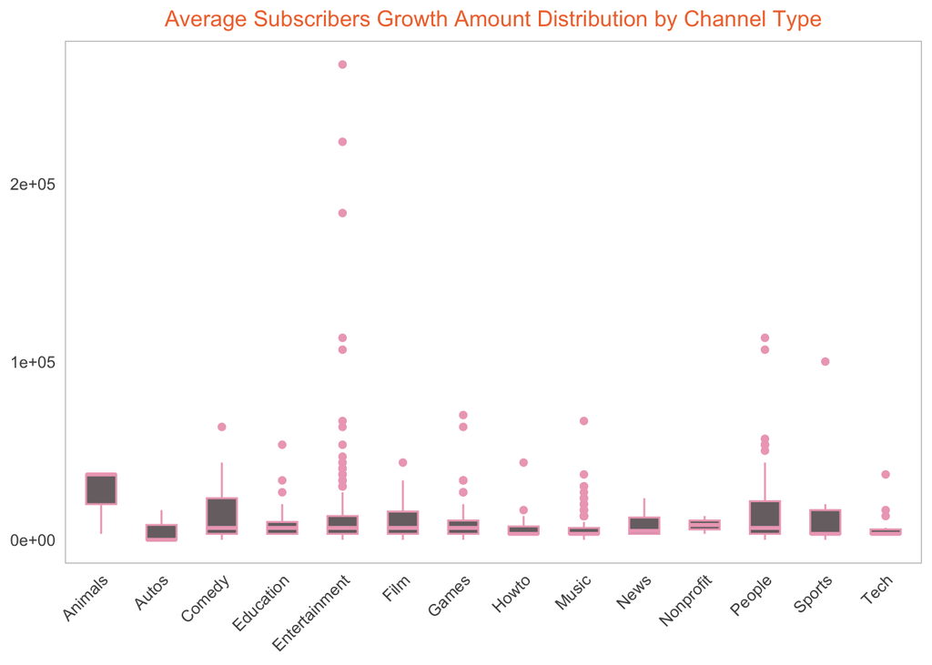

```r
max_y <- max(youtubedata$subscribers_growth_average_30, na.rm = TRUE)

p9 <- ggplot(youtubedata, aes(x = channel_type, y = subscribers_growth_average_30, fill = channel_type)) +
  geom_boxplot(width = 0.5, fill = "#786f72", color = "#eda8bf") +
  labs(
    x = "Channel Type",
    y = "Average Subscribers Growth Amount (30 days)",
    title = "Average Subscribers Growth Amount Distribution by Channel Type"
  ) +
  theme_minimal() +
  theme(
    panel.grid = element_blank(),
    panel.background = element_blank(),
    panel.border = element_rect(color = "grey", fill = NA),
    plot.title = element_text(color = "#f07237", size = 12, hjust = 0.5),
    axis.text.x = element_text(angle = 45, hjust = 1),
    axis.title.x = element_blank(),
    axis.title.y = element_blank()
  ) +
  scale_fill_manual(values = rainbow(length(unique(youtubedata$channel_type))) )
p9 <- p9 + coord_cartesian(ylim = c(0, max_y))
print(p9)
```

[figure not shown]

```r
p13 <- ggplot(delete_data_1, aes(x = subscribers_growth_average_30)) +
  geom_density(alpha = 0.5, fill = "#786f72", color = "#eda8bf") +
  labs(
    x = "Average Subscribers Growth Amount (30 days)",
    y = "Density",
    title = "Overall Density Plot of Average Subscribers Growth Amount (30 days)"
  ) +
  theme_minimal() +
  theme(
    panel.grid = element_blank(),
    panel.background = element_blank(),
    panel.border = element_rect(color = "grey", fill = NA),
    plot.title = element_text(color = "#f07237", size = 10, hjust = 0.5),
    axis.text.x = element_text(angle = 45, hjust = 1),
    axis.title.x = element_blank(),
    axis.title.y = element_blank()
  )

print(p13)
```

Due to the presence of outliers in the raw data, the box plot may not effectively reveal the distribution pattern. Next, we will create a plot using data that has been cleaned by removing values beyond 2 standard deviations.

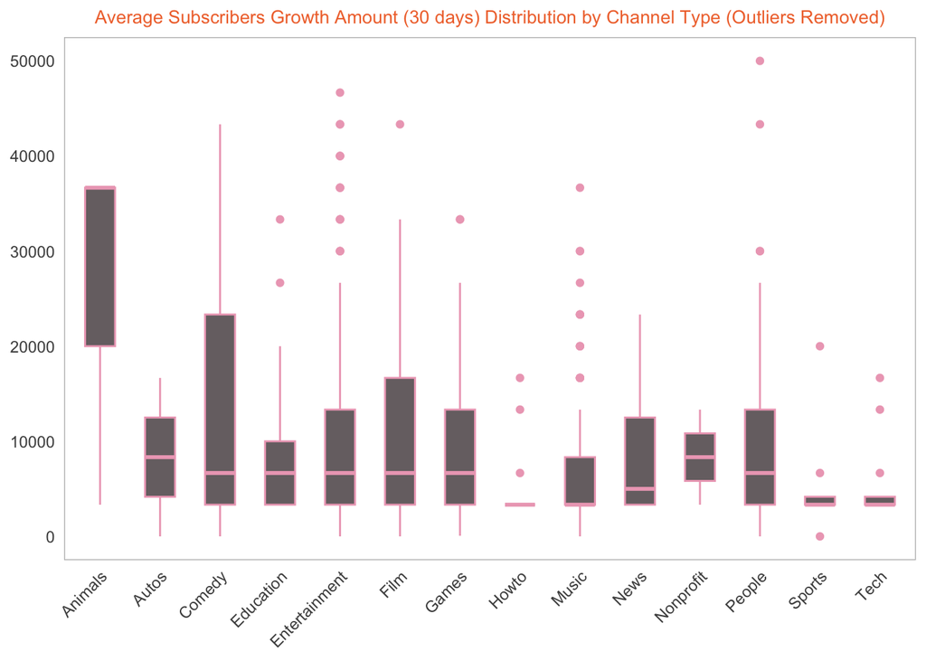

```r
p11 <- ggplot(delete_data_1, aes(x = channel_type, y = subscribers_growth_average_30, fill = channel_type)) +
  geom_boxplot(width = 0.5, fill = "#786f72", color = "#eda8bf")  +
  labs(
    x = "Channel Type",
    y = "Average Subscribers Growth Amount (30 days)",
    title = "Average Subscribers Growth Amount (30 days) Distribution by Channel Type (Outliers Removed)"
  ) +
  theme_minimal() +
  theme(
    panel.grid = element_blank(),
    panel.background = element_blank(),
    panel.border = element_rect(color = "grey", fill = NA),
    plot.title = element_text(color = "#f07237", size = 10, hjust = 0.5),
    axis.text.x = element_text(angle = 45, hjust = 1),
    axis.title.x = element_blank(),
    axis.title.y = element_blank()
  ) +
  scale_fill_manual(values = rainbow(length(unique(delete_data_1$channel_type))) )
print(p11)
```

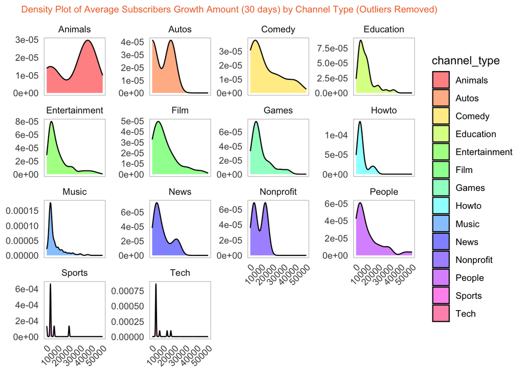

```r
p12 <- ggplot(delete_data_1, aes(x = subscribers_growth_average_30, fill = channel_type)) +
  geom_density(alpha = 0.5) +
  labs(
    x = "Average Subscribers Growth Amount (30 days)",
    y = "Density",
    title = "Density Plot of Average Subscribers Growth Amount (30 days) by Channel Type (Outliers Removed)"
  ) +
  theme_minimal() +
  theme(
    panel.grid = element_blank(),
    panel.background = element_blank(),
    panel.border = element_rect(color = "grey", fill = NA),
    plot.title = element_text(color = "#f07237", size = 9, hjust = 0.5),
    axis.text.x = element_text(angle = 45, hjust = 1),
    axis.title.x = element_blank(),
    axis.title.y = element_blank()
  ) +
  scale_fill_manual(values = rainbow(length(unique(delete_data_1$channel_type)))) +
  facet_wrap(~ channel_type, scales = "free_y") +
  xlim(0, NA)

print(p12)
```

Most of the data exhibits a right-skewed distribution.Create the overall daily subscription growth density curves without categorizing by channel type.

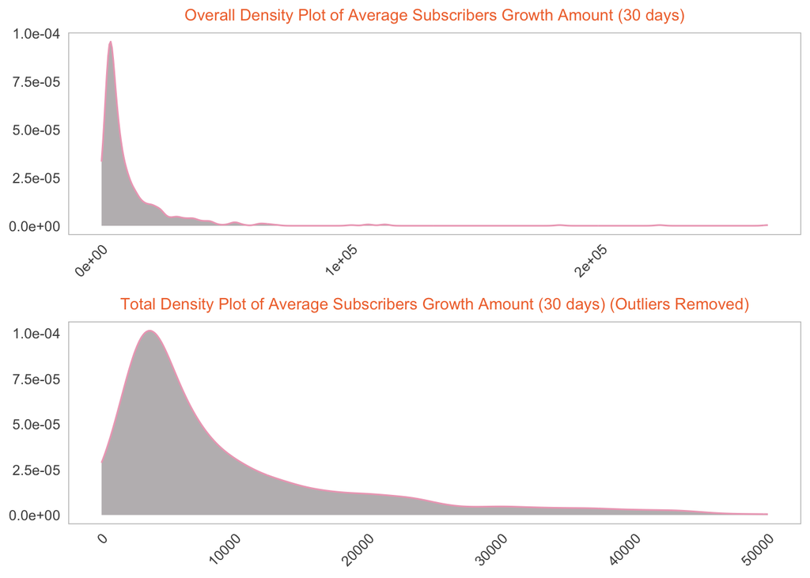

```r
p12_total <- ggplot(delete_data_1, aes(x = subscribers_growth_average_30)) +
  geom_density(alpha = 0.5, fill = "#786f72", color = "#eda8bf") +
  labs(
    x = "Average Subscribers Growth Amount (30 days)",
    y = "Density",
    title = "Total Density Plot of Average Subscribers Growth Amount (30 days) (Outliers Removed)"
  ) +
  theme_minimal() +
  theme(
    panel.grid = element_blank(),
    panel.background = element_blank(),
    panel.border = element_rect(color = "grey", fill = NA),
    plot.title = element_text(color = "#f07237", size = 10, hjust = 0.5),
    axis.text.x = element_text(angle = 45, hjust = 1),
    axis.title.x = element_blank(),
    axis.title.y = element_blank()
  ) +
  xlim(0, NA)

p13 <- ggplot(youtubedata, aes(x = subscribers_growth_average_30)) +
  geom_density(alpha = 0.5, fill = "#786f72", color = "#eda8bf") +
  labs(
    x = "Average Subscribers Growth Amount (30 days)",
    y = "Density",
    title = "Overall Density Plot of Average Subscribers Growth Amount (30 days)"
  ) +
  theme_minimal() +
  theme(
    panel.grid = element_blank(),
    panel.background = element_blank(),
    panel.border = element_rect(color = "grey", fill = NA),
    plot.title = element_text(color = "#f07237", size = 10, hjust = 0.5),
    axis.text.x = element_text(angle = 45, hjust = 1),
    axis.title.x = element_blank(),
    axis.title.y = element_blank()
  )
grid.arrange(p13, p12_total, ncol = 1)
```

## 5.7 Distribution of youtuber creation year

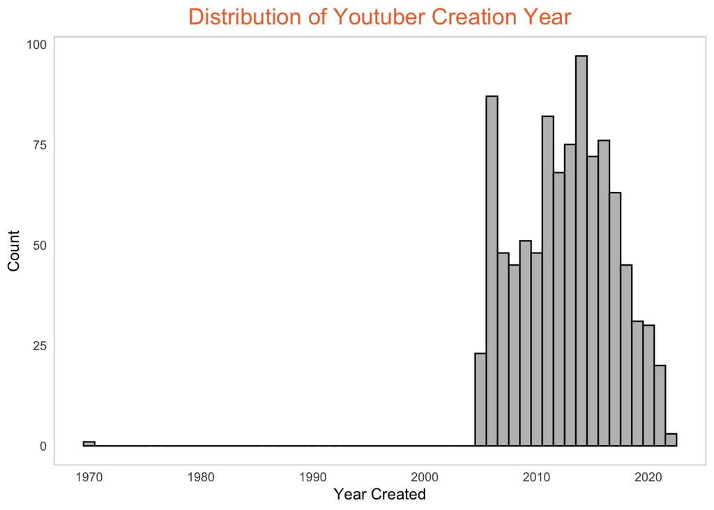

```r
p14 <- ggplot(youtubedata, aes(x = created_year)) +
  geom_histogram(binwidth = 1, fill = "grey", color = "black") +
  labs(
    x = "Year Created",
    y = "Count",
    title = "Distribution of Youtuber Creation Year"
  ) +
  theme_minimal() +
  theme(
    panel.grid = element_blank(),
    panel.background = element_blank(),
    panel.border = element_rect(color = "grey", fill = NA),
    plot.title = element_text(color = "#f07237", size = 16, hjust = 0.5)
  )

print(p14)
```

You can see that most Youtubers started their channels between 2004 and 2022. Let’s exclude the data before 2004 and analyze its distribution

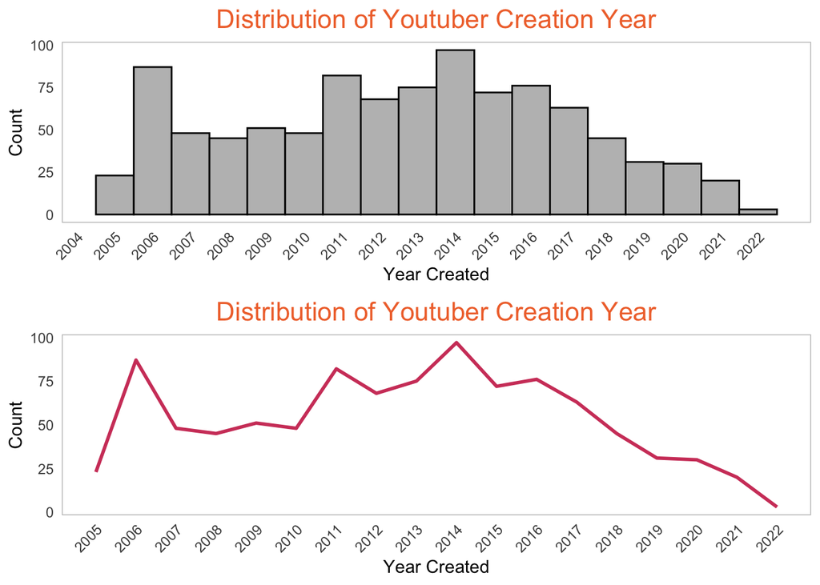

```r
p15 <- ggplot(youtubedata[youtubedata$created_year >= 2004, ], aes(x = created_year)) +
  geom_histogram(binwidth = 1, fill = "grey", color = "black") +
  labs(
    x = "Year Created",
    y = "Count",
    title = "Distribution of Youtuber Creation Year"
  ) +
  scale_x_continuous(breaks = seq(2004, max(youtubedata$created_year), by = 1)) +
  theme_minimal() +
  theme(
    panel.grid = element_blank(),
    panel.background = element_blank(),
    panel.border = element_rect(color = "grey", fill = NA),
    plot.title = element_text(color = "#f07237", size = 16, hjust = 0.5),
    axis.text.x = element_text(angle = 45, hjust = 1)  # 旋转 x 轴标签
  )

p16 <- ggplot(youtubedata[youtubedata$created_year >= 2004, ], aes(x = created_year)) +
  geom_line(stat = "count", color ="#d14369", size = 1) +
  labs(
    x = "Year Created",
    y = "Count",
    title = "Distribution of Youtuber Creation Year"
  ) +
  scale_x_continuous(breaks = seq(2004, max(youtubedata$created_year), by = 1)) +
  theme_minimal() +
  theme(
    panel.grid = element_blank(),
    panel.background = element_blank(),
    panel.border = element_rect(color = "grey", fill = NA),
    plot.title = element_text(color = "#f07237", size = 16, hjust = 0.5),
    axis.text.x = element_text(angle = 45, hjust = 1)
  )

grid.arrange(p15, p16, ncol = 1)
```

We can observe that the years in which youtubers started their channels (2004-2022) approximate a normal distribution, with the mode being in 2014. However, there is also a small peak in 2006

## 5.8 Relationships between the year of youtuber creation and four different “ranks”

Using the median of ranking data to represent ranking values.

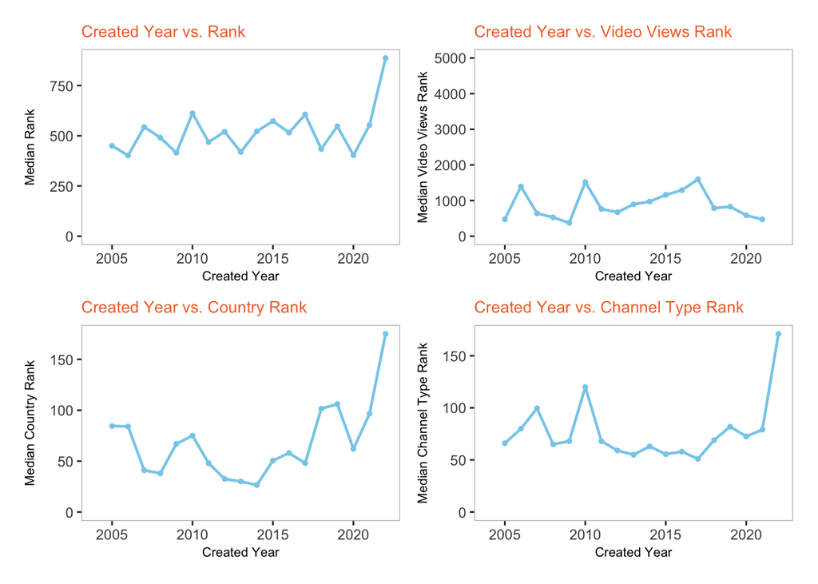

```r
lineplot_median_rank <- ggplot(median_rank_by_year, aes(x = created_year, y = median_rank)) +
  geom_point(color = "skyblue", size = 1, shape = 19) +
  geom_line(color = "skyblue", size = 0.8) +
  labs(title = "Created Year vs. Rank", x = "Created Year", y = "Median Rank") +
  xlim(2004, max(youtubedata$created_year)) +
  ylim(0, max(median_rank_by_year$median_rank)) +
  common_theme_3

lineplot_median_views_rank <- ggplot(median_rank_by_year, aes(x = created_year, y = median_views_rank)) +
  geom_point(color = "skyblue", size = 1, shape = 19) +
  geom_line(color = "skyblue", size = 0.8) +
  labs(title = "Created Year vs. Video Views Rank", x = "Created Year", y = "Median Video Views Rank") +
  xlim(2004, max(youtubedata$created_year)) +
  ylim(0, 5000) +
  common_theme_3

lineplot_median_country_rank <- ggplot(median_rank_by_year, aes(x = created_year, y = median_country_rank)) +
  geom_point(color = "skyblue", size = 1, shape = 19) +
  geom_line(color = "skyblue", size = 0.8) +
  labs(title = "Created Year vs. Country Rank", x = "Created Year", y = "Median Country Rank") +
  xlim(2004, max(youtubedata$created_year)) +
  ylim(0, max(median_rank_by_year$median_country_rank)) +
  common_theme_3


lineplot_median_channel_type_rank <- ggplot(median_rank_by_year, aes(x = created_year, y = median_channel_type_rank)) +
  geom_point(color = "skyblue", size = 1, shape = 19) +
  geom_line(color = "skyblue", size = 0.8) +
  labs(title = "Created Year vs. Channel Type Rank", x = "Created Year", y = "Median Channel Type Rank") +
  xlim(2004, max(youtubedata$created_year)) +
  ylim(0, max(median_rank_by_year$median_channel_type_rank)) +
  common_theme_3

combined_median_lineplot <-
  cowplot::plot_grid(
    lineplot_median_rank, lineplot_median_views_rank, lineplot_median_country_rank, lineplot_median_channel_type_rank,
    ncol = 2, align = "hv"
  ) +
  theme(plot.margin = margin(10, 10, 10, 10))


print(combined_median_lineplot)
```

It can be observed that after 2020, except for ‘video views rank,’ the ranking values of other categories have increased. This indicates a decline in rankings

# 6 Geographical information

## 6.1Count the number of YouTubers for each continent/ocean

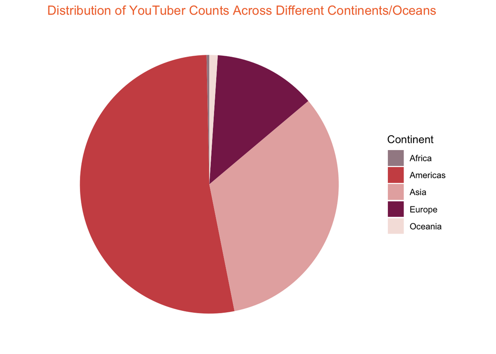

```r
youtubedata$Continent <- countrycode(youtubedata$Country, origin = "country.name", destination = "continent")
continent_counts <- table(youtubedata$Continent)
continent_counts_df <- data.frame(Continent = names(continent_counts), Count = as.numeric(continent_counts))
p17<- ggplot(continent_counts_df, aes(x = "", y = Count, fill = Continent)) +
  geom_bar(stat = "identity", width = 1) +
  coord_polar(theta = "y") +
  labs(title = "Distribution of YouTuber Counts Across Different Continents/Oceans", fill = "Continent") +
  theme_minimal() + common_theme_4 +
  theme(axis.title.x = element_blank(),
        axis.text.x = element_blank(),
        axis.title.y = element_blank(),
        axis.text.y = element_blank()) +
  scale_fill_manual(values = c("Africa" ="#a38b93", "Asia" = "#e6b0af", "Europe" = "#872657", "Americas" = "#cd5252", "Oceania" = "#f5e2de"))
print(p17)
```

We can see that youtubers from the Americas make up more than half, while Africa has the fewest.

## 6.2 Geographical Distribution of YouTubers’ Countries

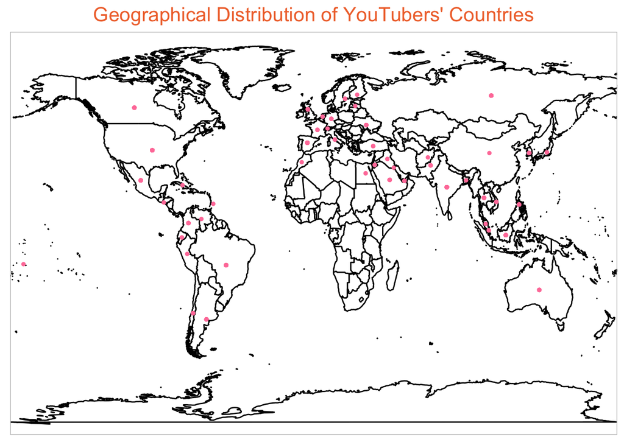

```r
world_map <- map_data("world")

p18<- ggplot() +
  geom_polygon(data = world_map, aes(x = long, y = lat, group = group),
               fill = "white", color = "black") +
  geom_point(data = youtubedata, aes(x = Longitude, y = Latitude), size = 1, color = "#ff7fa7") +
  labs(title = "Geographical Distribution of YouTubers' Countries") +
  theme_minimal() + common_theme +
  theme(axis.title = element_blank(),
        axis.text = element_blank())
p18 + coord_cartesian(xlim = c(-180, 180), ylim = c(-90, 90), expand = FALSE)
```

# 7 Reference

In the data analysis process, syntax generated by Chart GPT was referenced, replacing some of the variables within it.

# 8 Shinny app

The code can be seen and executed in the RMD file. ## link https://youtu.be/cHmA1A4hW-8